# BIOST 2079 Final Project

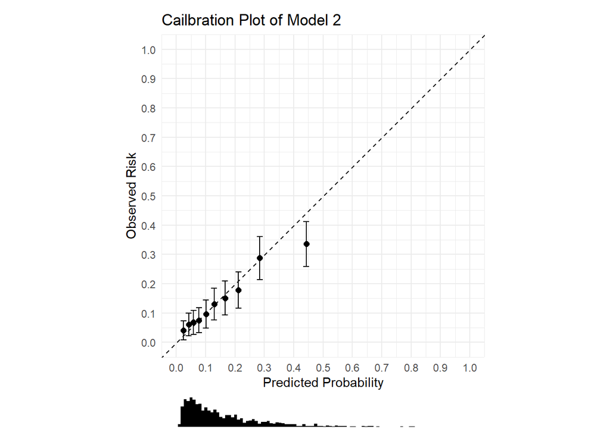

```r
# calibrate
cal_plot(test,
         outcome = 'TenYearCHD',
         prediction = 'pred2',
         plot_title = "Cailbration Plot of Model 2")
```

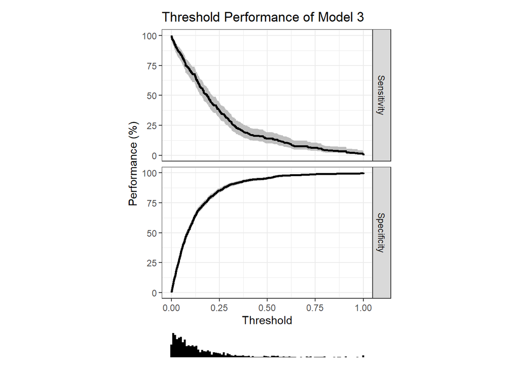

```r
# Slight underestimating but could argue it is well calibrated
# model 3
# threshold
threshperf_plot(test,
         outcome = 'TenYearCHD',
         prediction = 'pred3',
         plot_title = "Threshold Performance of Model 3")
```

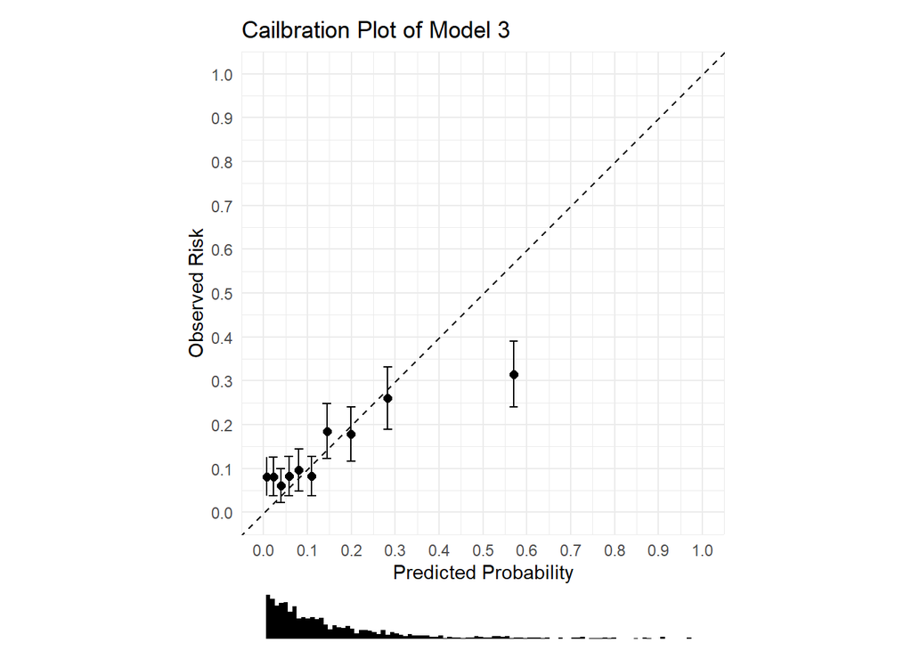

```r
# calibrate
cal_plot(test,
         outcome = 'TenYearCHD',
         prediction = 'pred3',
         plot_title = "Cailbration Plot of Model 3")
```

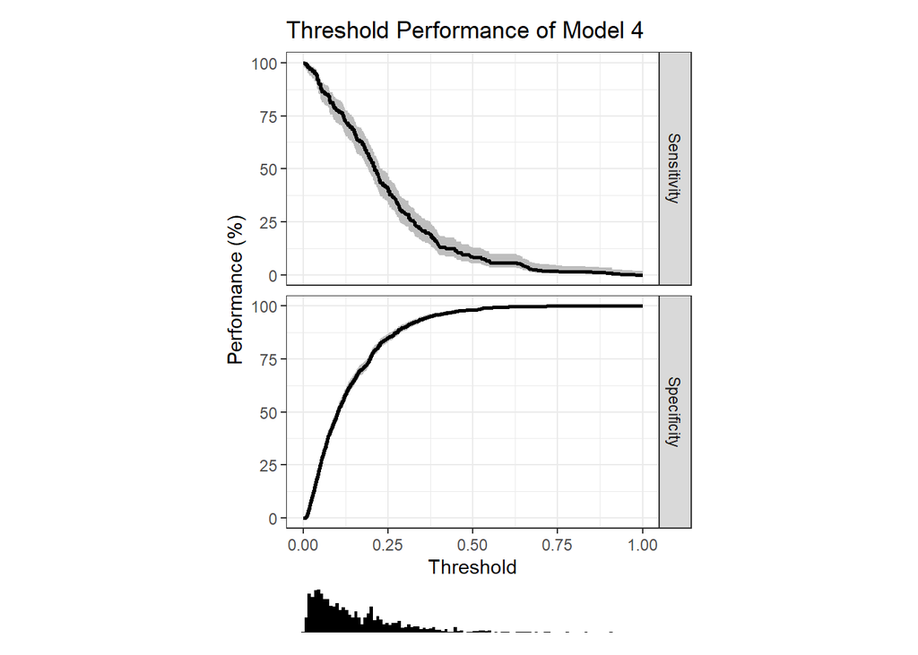

```r
# Underestimating again. Could be over fit.
# model 4
# threshold
threshperf_plot(test,
         outcome = 'TenYearCHD',
         prediction = 'pred4',
         plot_title = "Threshold Performance of Model 4")
```

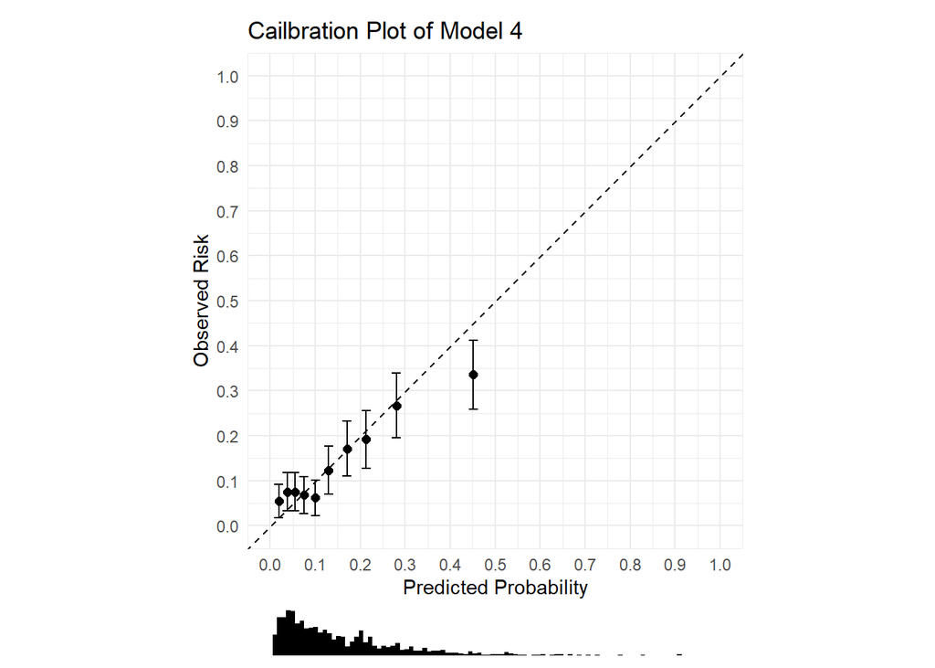

```r
# calibrate
cal_plot(test,
         outcome = 'TenYearCHD',
         prediction = 'pred4',
         plot_title = "Cailbration Plot of Model 4")
```

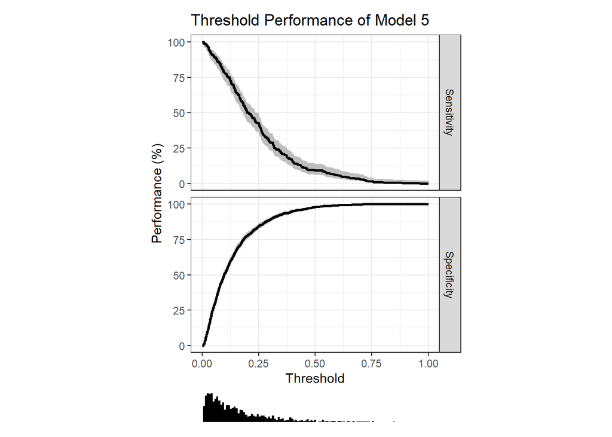

```r
# Looks pretty good
# model 5
# threshold
threshperf_plot(test,
         outcome = 'TenYearCHD',
         prediction = 'pred5',
         plot_title = "Threshold Performance of Model 5")
```

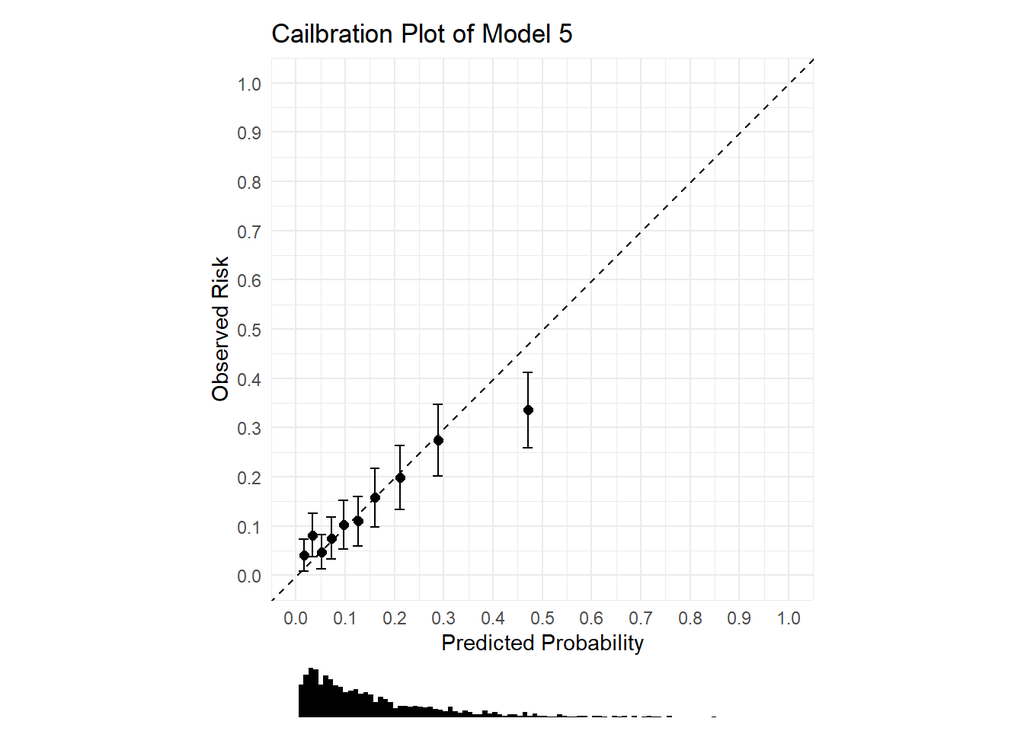

```r
# calibrate
cal_plot(test,
         outcome = 'TenYearCHD',
         prediction = 'pred5',
         plot_title = "Cailbration Plot of Model 5")
```

```r
# Underestimating

# creating confusion matrix
p1<- confusionMatrix(data=as.factor(test$pred1.bin), reference = test$TenYearCHD )
p2<- confusionMatrix(data=as.factor(test$pred2.bin), reference = test$TenYearCHD )
p3<- confusionMatrix(data=as.factor(test$pred3.bin), reference = test$TenYearCHD )
p4<-confusionMatrix(data=as.factor(test$pred4.bin), reference = test$TenYearCHD )
p5 <- confusionMatrix(data=as.factor(test$pred5.bin), reference = test$TenYearCHD )
```

## Conclusions - Best Model Summary

Of all the models, mod2 performed best on out of sample data. Model 2 was the logistic regression model containing only the significant features (as determined by mod1, which consisted of all additive inputs).

```r
summary(mod2)
```

```
##
## Call:
## glm(formula = TenYearCHD ~ male + age + cigsPerDay + totChol +
##     sysBP + glucose, family = "binomial", data = train)
##
## Deviance Residuals:
##     Min       1Q   Median       3Q      Max
## -2.1249  -0.6059  -0.4289  -0.2616   2.7488
##
## Coefficients:
##              Estimate Std. Error z value Pr(>|z|)
## (Intercept) -9.959425   0.635300 -15.677  < 2e-16 ***
## male1        0.681773   0.139075   4.902 9.48e-07 ***
## age          0.071096   0.008272   8.595  < 2e-16 ***
## cigsPerDay   0.019110   0.005455   3.503 0.000460 ***
## totChol      0.003893   0.001418   2.744 0.006061 **
## sysBP        0.018062   0.002794   6.464 1.02e-10 ***
## glucose      0.007937   0.002149   3.694 0.000221 ***
## ---
## Signif. codes:  0 '***' 0.001 '**' 0.01 '*' 0.05 '.' 0.1 ' ' 1
##
## (Dispersion parameter for binomial family taken to be 1)
##
##     Null deviance: 1922.1  on 2192  degrees of freedom
## Residual deviance: 1668.0  on 2186  degrees of freedom
## AIC: 1682
##
## Number of Fisher Scoring iterations: 5
```

As we can see, sex, age, cigarette count per day, total cholesterol, systolic blood pressure, and glucose levels are all important in prediction 10-year CHD risk.

## Limitations / Future Directions

Models - instead of diving deep into one model class (ex: KNN tuning), we decided to fit a bunch of models using many different techniques. - could have tried different combinations of inputs, different methods in order to try and get best predictions - instead, only went in-depth for logistic regression, and treated KNN and RF as supplementary approaches

Evaluation - only performed a single train/test split for the logistic regression models